# Assignment 1 Advanced Statistical Modeling

Jacolien van Rij Deadline: December 3, 2018

## Preparations

- Download the answer template (R Markdown) from Nestor and use that for creating your report. More information on R Markdown can be found here.
- Other directions for the R Markdown report:
  - Always include the code when you calculated or plotted information.
  - Do not include very long output - use `head` and similar functions to cut-off the output.
  - Use the html mark up `<ans>` for providing your answer to questions.
- Download the data and load it in R:

```r
# clean R working environment:
rm(list=ls())

# set working directory:
setwd("/Users/jacolien/Documents/Courses/AdvancedStatsModeling/Topic 1 LM/assignment/")

# Load data:
load("data_herlambang_behavioral.rda")

# Load packages:
library(plyr)
```

- The assignment is divided in sub questions, which sum up to 20 points. The assignment will count for 5% of the end grade. Skipping the assignment will result in 0 points.

#### The data

In this assignment we will explore the reaction times and responses of a vowel counting task by Herlambang, M.B., Taatgen, N.A., and Cnossen, F. (in preparation).

In each trial, participants were presented with three consecutive 12-letter pseudowords on a computer screen consisting of a randomized sequence of seven vowels (randomly drawn from *a*, *i*, *u*, and *e*) and five consonants (randomly drawn from all 21 consonants in the English alphabet) (see Figure 1). In each pseudoword, each of the four vowels appeared one to three times. Participants were asked to count how often two vowels, specified at the start of each trial, appeared in the three pseudowords in total. This target vowel set always included the vowel *a*, while the other vowel was randomly drawn among *i*, *u*, or *e*.

At the end of each trial, participants were asked to report the total number of the target vowels separately in an answer input screen as fast as possible. If participants knew the answer before the answer input screen appeared (i.e., within the time the last pseudoword was still being presented), they could press the space bar to call up the answer screen. Participants had two seconds to input their answer in the answer screen, and received feedback showing the correct answer.

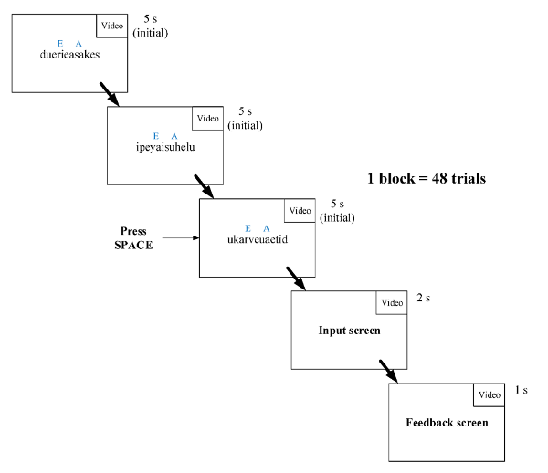

**Figure 1:** Schematic representation of a trial.

## Question 1: Descriptive statistics [5pt]

First, you are asked to check and visualize the data.

#### Q1a [1pt]

Inspect the data and answer the following questions. (Include the code and the answers in your report.)

- How many participants are included in the data? How many trials and blocks did each participant do?
- The column `condition` marks whether the participant received a reward in this block or not. In which blocks were rewards given? Did all participants receive a reward in the same block?

#### Q1b [1pt]

The column `response_space` marks whether the space bar was pressed to enter the response (‘Space’), or whether the participant waited until the answer prompt automatically appeared (‘None’). Depending on the number of errors, the time until the answer prompt appeared was slowly reduced.

The code below provides the code for the average proportion that the space bar was pressed per block. We will only include the trials for which at least one of the two counts is correct (i.e., correct is 0.5 for one counter correct, or 1 for both counters correct).

```r
dat.cor <- droplevels(dat[dat$correct > 0,])

avg <- ddply(dat[dat$correct > 0,], c("block", "condition"),
             summarise,
             space=mean(response_space=="space", na.rm=FALSE))
```

Running the following code will visualize the averages.

```r
# setup empty plot:
plot(c(),c(),
          xlim=range(avg$block), ylim=c(0.5,1),
          main="Pressed space bar",
          ylab="Proportion", xlab="Block",
          bty='n')
# add the gray line:
lines(avg$block, avg$space, col='gray')
# add lines and points for each condition:
with(avg[avg$condition=="reward",], # with(<data>, <do something>), see help(with)
     lines(block, space, lwd=1.5, lty=3, type='o', pch=21, bg='white', col=2))
with(avg[avg$condition=="no_reward",],
     lines(block, space, lwd=1.5, lty=3, type='o', pch=15, bg='white', col=1))
# add legend:
legend('topright', legend=c("reward", "no reward"),
       lwd=1.5, col=2:1, pch=c(21,15), pt.bg="white", bty='n')
```

- Inspect the plot. Describe the effect of condition and block on the proportion of space bar being pressed.

#### Q1c [3pt]

The column `response_time_space` indicates the *response latency* when the space bar was was pressed, or when the automatic prompt appeared. The time until the automatic prompt appeared was slowly decreased unless to many errors were made.

- Calculate the mean response latency per `block`, `condition`, and `response_space` (only for the responses that are (partly) correct, so using data `dat.cor`).
- Visualize how the response latencies change per condition, per block, and per response condition (i.e., `response_space`). You can decide yourself which type of plot to use, but the plot needs to meet the following criteria:
  - Distinguish between the two reward conditions;
  - Distinguish between the two response conditions (space / None);
  - Visualize the effect of block;
  - Add labels for the axes and a title;
  - Add a legend (function `legend`).

Include the code and the plot in your report.

## Question 2: Preparing data for analysis [5pt]

#### Q2a [2pt]

- Plot the distribution of the reaction times using a QQ-plot (functions `qqnorm` and `qqline`). Include the plot and the code in your report.
- Are the reaction times following a normal distribution? Describe how you can see in the QQ-plot whether the reaction times follow a normal distribution.

#### Q2b [3pt]

- Inspect the reaction times. Include the code in your report.
- Are there obvious outliers (i.e., values that are clearly problematic)? Explain why you think these points are outliers. If there are any clear outliers, remove these from the data. Include the code in your report.

We transform the reaction times using a log-transform:

```r
dat.cor$logRT <- log(dat.cor$response_time_space)
```

However, the log-transform does not seem to result in a better approximation of normally distributed data.

- Name a characteristic of this set of reaction times that make it difficult to transform the data so that it approximates a normal distribution. (Hint: Plot a histogram if you cannot see it in the QQ plot.)

## Question 3: Linear regression model [6pt]

To investigate whether the predictors `block` and `condition` influence the response latencies, we set-up a linear model that includes these predictors, and also the predictor `response_space`, and all the interactions between the three predictors. The model is fit on the *untransformed* reactions times of the data frame `dat.cor` (after excluding outliers in question 2b, if you considered this necessary).

#### Q3a [4pt]

```r
m1 <- lm(..., data=dat.cor)
summary(m1)
```

- Replace the dots (`'...'`) by the model formula and run the code. Include the code for the statistical model and the output of the summary in your report.
- Answer the following questions: - What is represented by the intercept? - What does the estimate `block` represent? What can you conclude from it’s value in the summary? - What does the estimate `response_spacespace` represent? What can you conclude from it’s value in the summary? - What does the estimate `block:conditionreward` represent? What can you conclude from it’s value in the summary? (Hint: for this question you can ignore the other interactions, and just focus on this estimate.)

#### Q3b [2pt]

- Use a QQ-plot to visualize the distribution of the residuals of the model. Hint: you can extract the residuals from the model using `resid(m1)`.
- Compare the QQ-plot of the residuals with a QQ-plot of the input data (i.e., the dependent variable, the un-transformed reaction times; see Question 2a). The distribution of the residuals looks much closer to the normal distribution than the original data. Why do the residuals show a different pattern as the data?

## Question 4: Visualize estimates [4pt]

#### Q4a [2pt]

The code is provided below for extracting the fitted effects for each condition:

```r
# create a new data file:
newd <- expand.grid(block = 1:14,
                    condition = c("reward", "no_reward"),
                    response_space=c("space", "None"), stringsAsFactors = FALSE)

# generate predictions (fitted values) for each condition:
fv <- predict(m1, newd, se.fit=TRUE)
newd$fit <- fv$fit
newd$se  <- fv$se.fit

head(newd)
```

- What are the fitted effects of a statistical model? (They can be extracted using `fitted`, but also with `predict`.)
- Plot the model estimates of `newd`. Include the code and the plot in your report.

#### Q4b [2pt]

- Based on the plots, explain which predictor has the largest influence on the participants’ reaction times.
- Describe in words the interaction between `block`, `condition`, and `response_space`. Hint: look at the plot.